# Reproducible Research: Peer Assessment 1

Jeffrey Strickland

12/27/2021

```r
knitr::opts_chunk$set(fig.width=8, fig.height=5, echo=TRUE, warning=FALSE) #global parameters
```

## Data Preprocessing

### *Load required packages*

```r
library(readr)
library(dplyr)
library(zoo)
```

### *Check the working directory*

```r
getwd()
```

```
## [1] "C:/Users/jeff/Documents/R/Repro_Research/RepData_PeerAssessment1"
```

### *Download and unzip the file*:

```r
filename = "activity.csv"
if (!file.exists(filename)){
    urlzip <- "https://d396qusza40orc.cloudfront.net/repdata%2Fdata%2Factivity.zip"
    download.file(urlzip, destfile = "./activity.zip" )
    unzip("./activity.zip", exdir = getwd() )
}
```

## Loading and preprocessing the data

- Set the path to match the working directory
- read filename that was unzipped above and indicate the header is present
- print the record of the activity file

```r
activity_main <- read.csv("./activity.csv", header = TRUE)
head(activity_main,5)
```

|  | steps | date | interval |
| --- | --- | --- | --- |
| 1 | NA | 2012-10-01 | 0 |
| 2 | NA | 2012-10-01 | 5 |
| 3 | NA | 2012-10-01 | 10 |
| 4 | NA | 2012-10-01 | 15 |
| 5 | NA | 2012-10-01 | 20 |

### *Make a Copy of Original Data*

It is always a good idea to not manipulate the original data file you upload (`activity_main`), so we make a copy:

```r
activity <- activity_main
```

### *Explore the Data*

- Note that there are numerous missing values (NAs) from the file printouts
- Since imputation will be dealt with more thoroughly later, let’s exclude the missing values for now
- Calculate the mean and total number of steps

```r
activity <- activity_main[!is.na(activity[, 1]), ]
act_count <- count(activity[, 0])
act_mean <- mean(activity[, 1])
act_sum <- sum(activity[, 1])
cat("Mean number of steps =",act_mean)
```

```
## Mean number of steps = 37.3826
```

```r
cat("Total number of steps =",act_sum)
```

```
## Total number of steps = 570608
```

```r
act_count
```

| n |
| --- |
| 15264 |

#### Let’s also look at the following:

- dimension
- structure
- summary statistics

```r
dim(activity)      # Dimension
```

```
## [1] 15264     3
```

```r
str(activity)      # Structure
```

```
## 'data.frame':    15264 obs. of  3 variables:
##  $ steps   : int  0 0 0 0 0 0 0 0 0 0 ...
##  $ date    : chr  "2012-10-02" "2012-10-02" "2012-10-02" "2012-10-02" ...
##  $ interval: int  0 5 10 15 20 25 30 35 40 45 ...
```

```r
summary(activity)  # Summary
```

```
##      steps            date              interval
##  Min.   :  0.00   Length:15264       Min.   :   0.0
##  1st Qu.:  0.00   Class :character   1st Qu.: 588.8
##  Median :  0.00   Mode  :character   Median :1177.5
##  Mean   : 37.38                      Mean   :1177.5
##  3rd Qu.: 12.00                      3rd Qu.:1766.2
##  Max.   :806.00                      Max.   :2355.0
```

## Mean Total Number of Steps per Day

Now let’s answer the question, **“What is mean total number of steps taken per day?”**

Note that by applying a filter `!is.na` as a filter, we can turn it off by commenting it out

```r
steps_by_date <- select(activity, steps, date, interval) %>%
  filter(!is.na(steps)) %>% # removed filter to include NAs as 0-step days in histogram
  group_by(date) %>%
  summarize(total_steps = sum(steps, na.rm = TRUE)) #has the same effect as `!is.na`
```

Second, using the total number of steps per day calculation, we can now compute the mean and median number of steps per day. Here, we assume that each date represents a day, and that there are mulutiple periods recored each day, i.e., the 5-minute intervals.

### *Mean-Median number of Steps per day*

Here, we use the complete.case() function as, previously mentioned to “remove” missing values

```r
steps_by_date <- activity[complete.cases(activity),] %>%
  group_by(date) %>%
  summarize(total_steps=sum(steps))
steps_by_date
```

| date | total_steps |
| --- | --- |
| 2012-10-02 | 126 |
| 2012-10-03 | 11352 |
| 2012-10-04 | 12116 |
| 2012-10-05 | 13294 |
| 2012-10-06 | 15420 |
| 2012-10-07 | 11015 |
| 2012-10-09 | 12811 |
| 2012-10-10 | 9900 |
| 2012-10-11 | 10304 |
| 2012-10-12 | 17382 |

[output cut: 43 more lines]

### *Calculate Mean and Median Total Steps per Day*

Next, we calculate and report the mean and median of the total number of steps taken per day. We compute them using the mean() and median() functions and name the computation, `MeanMedian_Raw`, for the unimputed data, and `MeanMedian_Imputed` (used later).

```r
MeanMedian_Raw <-
  activity[complete.cases(activity),] %>%
  group_by(date) %>%
  summarize(average_steps=mean(steps),median_steps=median(steps)) %>%
as.data.frame(MeanMedian_Raw)

mean_total_steps <- mean(steps_by_date$total_steps)
median_total_steps <- median(steps_by_date$total_steps)
cat("The mean of the total number of steps taken per day is ", mean_total_steps)
```

```
## The mean of the total number of steps taken per day is  10766.19
```

```r
cat("The median of the total number of steps taken per day is ", median_total_steps)
```

```
## The median of the total number of steps taken per day is  10765
```

### *Plot the histogram*

Here, we use R’s base function to plot a histogram of the total steps per day. We also add aesthetics, including * A plot title (main) * x and y labels * customer colors * breaks, which is a single number, treated as a suggestion as it gives pretty breakpoints

We also generate ablines using the `abline()` function, which can be used to add vertical, horizontal or regression lines to a graph. We add the vertical lines to the histogram we created earlier at the mean and median points. This also demonstrates how additional plotting objects can be added to an existing plot.

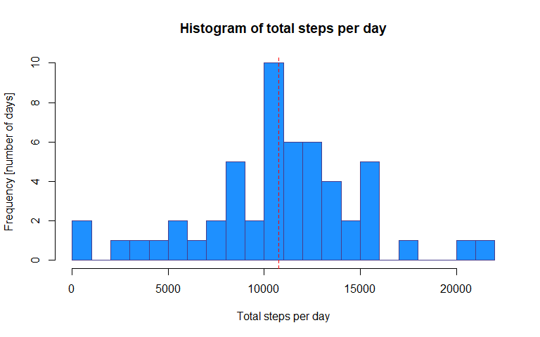

```r
hist(steps_by_date$total_steps,
     main = "Histogram of total steps per day",
     xlab = "Total steps per day",
     ylab = "Frequency [number of days]",
     breaks = 20,
     border = "slateblue4",
     col = "dodgerblue"
)
abline(v = mean_total_steps, lwd = 1, lty = 2, col = "red")
abline(v = median_total_steps, lwd = 1, lty = 2, col = "red")
```

## Average Daily Activity Pattern

Here, we answer the question, **“What is the average daily activity pattern?”**

To do so, we create a quasi time-series plot (the plot is technical a scatterplot, as the activity data is not properly formatted with a time-based index, which we could do using the `xts`-package). However, we will apply a 100-interval moving average to investigate how we might impute missing values with a mean value, for example.

### *Plot customization*

We’ll also customize the plot with the following aethetics: * A line type scatterplot using `type = "l"` * a wider line width, using `lwd` * a custom color, `royalblue4`, using `col` * a plot title, using `main` * x- and y-axis labels, with xlab and ylab, respectively * the 100-period moving average line, and * a customized legend

Finally, we will add vertical and horizontal lines, using abline(), representing the point where the maximum average steps occur.

```r
steps_by_interval <- select(activity, steps, date, interval) %>%
  group_by(interval) %>%
  summarize(average_steps = mean(steps, na.rm = TRUE))
dim0 <- dim(steps_by_interval)
cat("The dimension of steps_by_interval is: ", dim0)
```

```
## The dimension of steps_by_interval is:  288 2
```

Which 5-minute interval, on average across all the days in the dataset, contains the maximum number of steps?

```r
x <- steps_by_interval[steps_by_interval$average_steps==max(steps_by_interval$average_steps),1]
cat("The 5-minute interval with the maximum steps is: ", as.character(x))
```

```
## The 5-minute interval with the maximum steps is:  835
```

### *Time series plot*

[figure not shown]

```r
new_steps_100ma <- zoo::rollmean(activity["steps"], k = 100, fill = NA)
plot(steps_by_interval$interval, steps_by_interval$average_steps,
     type = "l",
     lwd  = 3,
     col  = 'royalblue4',
     main = 'Average Steps by 5-minute Interval', cex = .85,
     xlab = "Interval",
     ylab = "Average number of steps")
lines(new_steps_100ma, lwd = 4, col = 'red2')
legend('topright', deaths.xts,
       c('Steps', '100-period MA'),
       fill = c('blue2', 'red2', 'green2'), cex = .85,
       box.lty = 1)

max_average_steps <- max(steps_by_interval$average_steps)
max_average_steps_interval <- steps_by_interval[
  steps_by_interval$average_steps == max_average_steps,
]$interval
abline(v = max_average_steps_interval, lwd = 1, lty = 2, col = "red")
abline(h = max_average_steps, lwd = 1, lty = 2, col = "red")
```

### *Sample of some averages in steps_by_interval*:

```r
steps_by_interval[steps_by_interval$interval %in% c(1000,1500,2000,2500),]
```

| interval | average_steps |
| --- | --- |
| 1000 | 40.56604 |
| 1500 | 30.01887 |
| 2000 | 19.62264 |

```r
head(activity[which(is.na(activity$steps) & activity$interval %in% c(1000,1500,2000,2500)),], n = 30)
```

| steps | date | interval |
| --- | --- | --- |

## Imputing Missing Values

Here, we investigate the **effect of imputing missing `steps` values**,

### *Caclulate number of missing vales*

```r
x<-sum(is.na(activity[, 1]))
cat("Number of rows with missing values =",as.character(x))
```

```
## Number of rows with missing values = 0
```

### *Replace missing step values*

Here, we use the `mean()` function for a given interval, which we calculated above, to replace missing steps values (NAs). The object, `steps_by_interval`, contains means of steps for each interval (see above).

```r
steps_by_interval[steps_by_interval$interval %in% c(500,1000,1500,2000),]
```

| interval | average_steps |
| --- | --- |
| 500 | 0.00000 |
| 1000 | 40.56604 |
| 1500 | 30.01887 |
| 2000 | 19.62264 |

```r
steps_by_interval <- as.data.frame(steps_by_interval)
```

### *Create objject to hold imputed values*

Next, we create an object to hold activity and imputed activity.

```r
Imputed <- activity
```

### *Find and replace missing values*

Next, we find rows with missing (NA) data and replace them with the mean we calculate for the given for the intervals.

```r
for (i in 1:nrow(Imputed)) {
  if (is.na(Imputed$steps[i])){
    n <- steps_by_date[steps_by_date$interval==Imputed$interval[i],average_steps]
                           Imputed$steps[i]<- as.integer(round(n))
                           }
}
```

### *Define comparison data*

Now, we are ready to compare the data we just imputed with the work accomplished earlier. We proceed as follows. * Populate the Imputed object with NAs imputed * Redefine the data with NAs present * Redefine the data with NAs removed * Generate histograms for each set of data

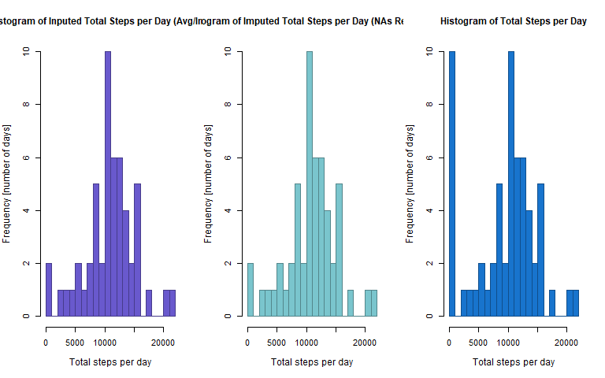

```r
steps_by_date_imp <- Imputed %>%
  group_by(date) %>%
  summarize(imp_total_steps=sum(steps))

steps_by_date_na <- select(activity_main, steps, date, interval) %>%
  #filter(!is.na(steps)) %>% # removed filter to include NAs as 0-step days in histogram
  group_by(date) %>%
  summarize(total_steps = sum(steps, na.rm = TRUE)) #has the same effect as `!is.na`

steps_by_date <- select(activity, steps, date, interval) %>%
  filter(!is.na(steps)) %>% # removed filter to include NAs as 0-step days in histogram
  group_by(date) %>%
  summarize(total_steps = sum(steps, na.rm = TRUE)) #has the same effect as `!is.na`

par(mfrow=c(1,3))

hist(steps_by_date_imp$imp_total_steps,
     main = "Histogram of Inputed Total Steps per Day (Avg/Interval)",
     xlab = "Total steps per day",
     ylab = "Frequency [number of days]",
     cex.main = 1.1,
     cex.lab = 1.1,
     breaks = 20,
     border = "slateblue4",
     col = "slateblue3"
)
hist(steps_by_date$total_steps,
     main = "Histogram of Imputed Total Steps per Day (NAs Removed)",
     xlab = "Total steps per day",
     ylab = "Frequency [number of days]",
     cex.main = 1.1,
     cex.lab = 1.1,
     breaks = 20,
     border = "cadetblue4",
     col = "cadetblue3"
)
hist(steps_by_date_na$total_steps,
     main = "Histogram of Total Steps per Day",
     xlab = "Total steps per day",
     ylab = "Frequency [number of days]",
     cex.main = 1.1,
     cex.lab = 1.1,
     breaks = 20,
     border = "dodgerblue4",
     col = "dodgerblue3"
)
```

### *Calculate and Report the Mean and Median Total Steps per Day*

```r
MeanMedian_Imputed <-
  Imputed %>%
  group_by(date) %>%
  summarize(average_steps=mean(steps),median_steps=median(steps))
MeanMedian_Imputed
```

| date | average_steps | median_steps |
| --- | --- | --- |
| 2012-10-02 | 0.4375000 | 0 |
| 2012-10-03 | 39.4166667 | 0 |
| 2012-10-04 | 42.0694444 | 0 |
| 2012-10-05 | 46.1597222 | 0 |
| 2012-10-06 | 53.5416667 | 0 |
| 2012-10-07 | 38.2465278 | 0 |
| 2012-10-09 | 44.4826389 | 0 |
| 2012-10-10 | 34.3750000 | 0 |
| 2012-10-11 | 35.7777778 | 0 |
| 2012-10-12 | 60.3541667 | 0 |

[output cut: 43 more lines]

#### *Do these values differ from the estimates from the first part of the assignment?*

There is no significant difference

```r
summary(MeanMedian_Raw,2:3)
```

```
##      date           average_steps      median_steps
##  Length:53          Min.   : 0.1424   Min.   :0
##  Class :character   1st Qu.:30.6979   1st Qu.:0
##  Mode  :character   Median :37.3785   Median :0
##                     Mean   :37.3826   Mean   :0
##                     3rd Qu.:46.1597   3rd Qu.:0
##                     Max.   :73.5903   Max.   :0
```

```r
summary(MeanMedian_Imputed,2:3)
```

```
##      date           average_steps      median_steps
##  Length:53          Min.   : 0.1424   Min.   :0
##  Class :character   1st Qu.:30.6979   1st Qu.:0
##  Mode  :character   Median :37.3785   Median :0
##                     Mean   :37.3826   Mean   :0
##                     3rd Qu.:46.1597   3rd Qu.:0
##                     Max.   :73.5903   Max.   :0
```

## Weekend and Weekday Activity Patterns

Now, we answer the question, “Are there differences in activity patterns between weekdays and weekends?”

For this part the weekdays() function may be of some help here. Use the dataset with the filled-in missing values for this part. Create a new factor variable in the dataset with two levels - “weekday” and “weekend” indicating whether a given date is a weekday or weekend day.

### *Create the names*

First, we define the names of the days in a week and corresponding descriptors, weekday and weekend. We also attend to the necessary data imputations along the line of our previous work.

```r
DayOfWeek <- data.frame(
  name=c("Monday","Tuesday","Wednesday","Thursday","Friday","Saturday","Sunday"),
  part=c("weekday","weekday","weekday","weekday","weekday","weekend","weekend"))

Imputed$date<-as.Date(Imputed$date)

## Create the column
Imputed$WeekPart <- as.factor(weekdays(Imputed$date))
## Set the value
Imputed$WeekPart <- DayOfWeek[Imputed$WeekPart,2]
```

### *Make a panel plot*

We also make a panel plot containing a time series plot (i.e. type = “l”) of the 5-minute interval (x-axis) and the average number of steps taken, averaged across all weekday days or weekend days (y-axis). To do this, we: * Calculate and store the means by group * Construct a lattice plot for weekend and weekdays

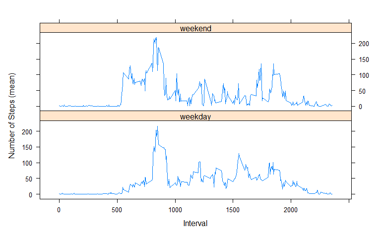

```r
PlotSummary <- Imputed %>%
  group_by(WeekPart,interval) %>%
  summarize(StepsMean=mean(steps))
## Use the lattice graphics for easier multiple panels
library(lattice)
xyplot(PlotSummary$StepsMean ~ PlotSummary$interval | PlotSummary$WeekPart,
       data=PlotSummary, type="l", layout=c(1:2),
       ylab="Number of Steps (mean)",
       xlab="Interval")
```